# Creating metacommunities

```r
library(flume)
```

The metacommunity is one of the two main components for creating a `flume` model. It describes the collection of species that can occur in the model, including all of their traits related to the niche, species interactions, and dispersal.

The easiest way to generate these components is by using `scenarios`, which you pass to the function `metacommunity()`. There are scenarios around resources and niches, and scenarios for dispersal. For example, the default behaviour when you call the `metacommunity()` function with no arguments is to create a metacommunity with 2 species and one resource using the `niches_uniform()` scenario for resources/niches and the `dispersal_custom()` dispersal scenario (using default parameters in this case that do not vary by species). The equivalent call specifying all parameters would be: `metacommunity(nsp = 2, nr = 1, niches = niches_uniform, dispersal = dispersal_custom)`. The niche scenario here will create niches that are uniformly spaced across the possible resource values, with a standard deviation chosen automatically to cover a moderate breadth.

## Niche shape

The niche contains two components, a colonisation and an extinction function. Currently, the only implemented shape is a `gaussian` colonisation function and a `constant` extinction function. Each of them has parameters:

### Gaussian

- scale: the maximum value of the curve
- location: where on the resource axis the peak of the curve is
- breadth: How broad (i.e., the standard deviation of the gaussian function)

### Constant

- scale: the height of the function

These parameters can be specified to vary by species, vary by resource axis, or both, and to have orthogonal or covarying resource axes. To change them individually, use the `niches_custom` scenario. Here, we change the location and breadth of the gaussian colonisation function to make three species, including two low-resource specialists that compete strongly and one generalist with a slight preference for high resource conditions, but a lower peak performance.

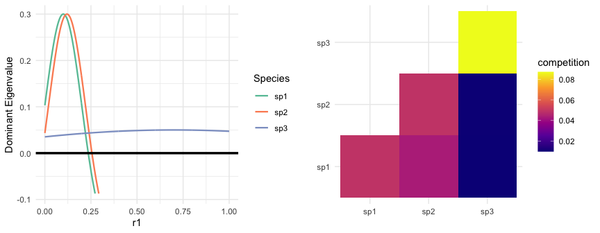

```r
library(ggplot2)
nopts = list(location = c(0.1, 0.12, 0.7), breadth = c(0.1, 0.1, 2), scale_c = c(0.5, 0.5, 0.25))
mcom = metacommunity(nsp = 3, nr = 1, niches = niches_custom, niche_args = nopts)
plot(mcom, lwd = 0.8, res = 500, xlim = c(0,1))
```

## Dispersal parameters

Species can disperse in the river network in two ways. **Active dispersal**, controlled by a parameter `alpha`, indicates the ability of a species to move under its own power; active dispersal occurs along the stream, in both up- and down-stream directions. Passive dispersal that occurs when one species is transported by another species should also be included in `alpha`. **Passive dispersal** is dispersal with the flow of water, and only occurs downstream. It is specified with a parameter `beta`. Both `alpha` and `beta` can be a scalar (all species have the same disperal ability) or a vector with one entry per species. We can change these parameters using the `dispersal_custom` scenario, in a similar manner as to the niches. Here we edit the previous community to make the specialists primarily passive dispersers, while the generalist is a strong disperser both up- and downstream.

```r
dopts = list(alpha = c(0.05, 0.05, 0.5), beta = 0.5)
mcom = metacommunity(nsp = 3, nr = 1, niches = niches_custom, dispersal = dispersal_custom,
  niche_args = nopts, dispersal_args = dopts)
```

### Complex resources

It isn’t always the case that resources map directly to niche axes. Here we load the `algae` dataset included with `flume`. The `niches` object gives average and standard deviation of N:P ratios for 5 aquatic algal taxa. We can create a metacommunity that tracks two resources, but computes the niche based on the ratio of these two resources.

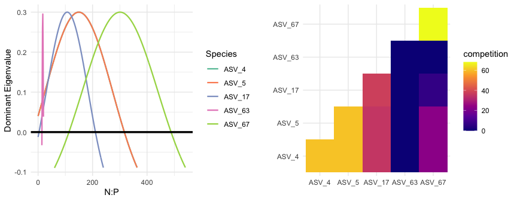

```r
data(algae)
nopts = list(location = algae$niches$location, breadth = algae$niches$breadth, ratio = c(1, 2))
mcom = metacommunity(nsp = nrow(algae$niches), nr = 2, niches = niches_custom, niche_args = nopts,
  sp_names = algae$niches$species, r_names = c("N", "P"))
plot(mcom, res = 500, lwd = 0.8)
```

### Static resources

Many species’ niches depend not only on depletable resources (e.g., nitrogen, organic matter), but also on (relatively) fixed features of the environment, such as light availability, riverbed composition, or the presence of pools. These features are not like resource concentrations: they cannot be transported downstream and they are not depeleted by organisms using them. `flume` represents these features as ‘resources’, but they are labelled as `'static'` in order to tell the model to use them for computing species’ niches, but to hold their amounts constant durint the transport-reaction phase.

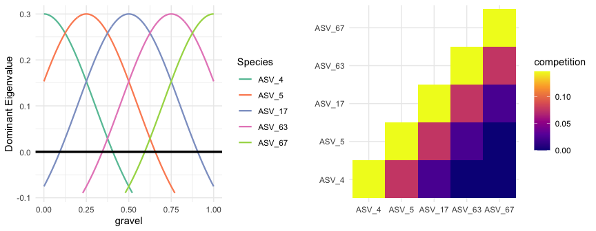

```r
nsp = nrow(algae$niches)
location = cbind(algae$niches$location, seq(0, 1, length.out = nsp))
breadth = cbind(algae$niches$location, 0.3)
nopts = list(location = location[,2], breadth = breadth[,2], static = 1)
mcom = metacommunity(nsp = nsp, nr = 1, niches = niches_custom, niche_args = nopts,
  sp_names = algae$niches$species, r_names = c("gravel"))
plot(mcom, res = 500, lwd = 0.8, xlim=c(0,1))
```

Finally, We could combine these two approaches to generate a multidimensional niche. However, we won’t run this code here; multidimensional niches are slow to generate, because they must be integrated numerically in multiple dimensions to generate the competition matrix.

```r
nopts = list(location = location, breadth = breadth, ratio = c(1,2), static = 3)
mcom = metacommunity(nsp = nsp, nr = 3, niches = niches_custom, niche_args = nopts,
  sp_names = algae$niches$species, r_names = c("N", "P", "gravel"))
```